# INN Hotels Project

**Perform feature engineering on arrival date.**

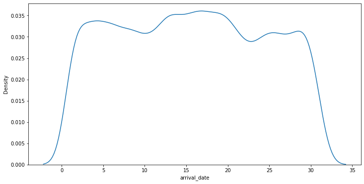

```python
plt.figure(figsize=(12, 6))
sns.kdeplot(data = hotel_data, x = 'arrival_date')
plt.show()
```

```python
hotel_data['arrival_date'] -= np.min(hotel_data['arrival_date'])
hotel_data['arrival_date'] /= np.max(hotel_data['arrival_date'])
```

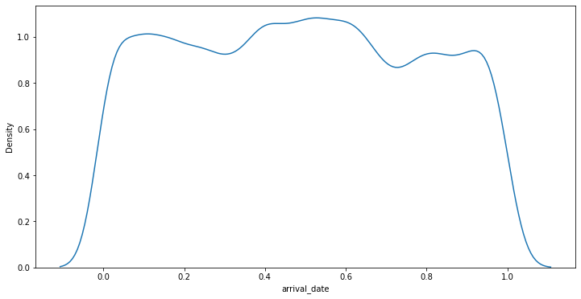

```python
plt.figure(figsize=(12, 6))
sns.kdeplot(data = hotel_data, x = 'arrival_date')
plt.show()
```

**Feature engineering on arrival date is complete.**

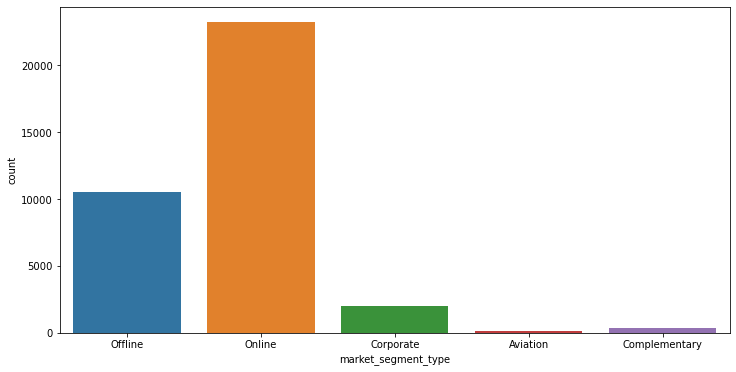

```python
plt.figure(figsize=(12, 6))
sns.countplot(data = hotel_data, x = 'market_segment_type')
plt.show()
```

**Perform one-hot encoding on the categorical feature.**

```python
encoder = OneHotEncoder()
```

```python
encoded_segment_type = encoder.fit_transform(hotel_data[['market_segment_type']]).toarray()
```

```python
encoded_df = pd.DataFrame(encoded_segment_type, columns = ['ST1', 'ST2', 'ST3', 'ST4', 'ST5'])
```

```python
encoded_df
```

|  | ST1 | ST2 | ST3 | ST4 | ST5 |
| --- | --- | --- | --- | --- | --- |
| 0 | 0.0 | 0.0 | 0.0 | 1.0 | 0.0 |
| 1 | 0.0 | 0.0 | 0.0 | 0.0 | 1.0 |
| 2 | 0.0 | 0.0 | 0.0 | 0.0 | 1.0 |
| 3 | 0.0 | 0.0 | 0.0 | 0.0 | 1.0 |
| 4 | 0.0 | 0.0 | 0.0 | 0.0 | 1.0 |
| ... | ... | ... | ... | ... | ... |
| 36270 | 0.0 | 0.0 | 0.0 | 0.0 | 1.0 |
| 36271 | 0.0 | 0.0 | 0.0 | 0.0 | 1.0 |
| 36272 | 0.0 | 0.0 | 0.0 | 0.0 | 1.0 |
| 36273 | 0.0 | 0.0 | 0.0 | 0.0 | 1.0 |
| 36274 | 0.0 | 0.0 | 0.0 | 1.0 | 0.0 |

36275 rows × 5 columns

```python
hotel_data = hotel_data.join(encoded_df)
```

```python
hotel_data.drop('market_segment_type', axis = 1, inplace = True)
```

**Perform feature engineering on repeated guest**

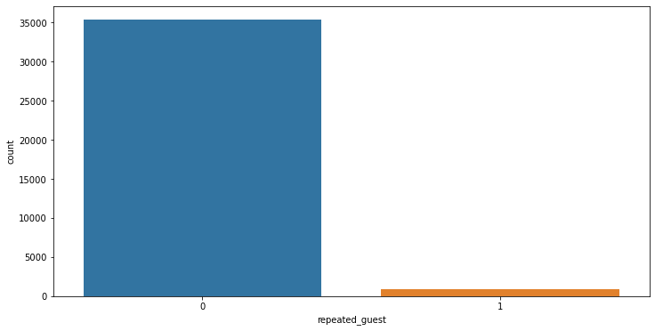

```python
plt.figure(figsize=(12, 6))
sns.countplot(data = hotel_data, x = 'repeated_guest')
plt.show()
```

**Nothing needs to be done to this field.**

**Perform feature engineering on number of previous cancellations.**

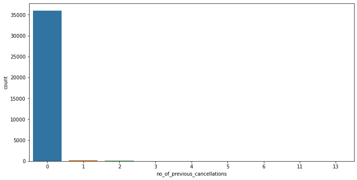

```python
plt.figure(figsize=(12, 6))
sns.countplot(data = hotel_data, x = 'no_of_previous_cancellations')
plt.show()
```

**Perfrom minmax scaling from 0 to 1.**

```python
hotel_data['no_of_previous_cancellations'] -= np.min(hotel_data['no_of_previous_cancellations'])
hotel_data['no_of_previous_cancellations'] /= np.max(hotel_data['no_of_previous_cancellations'])
```

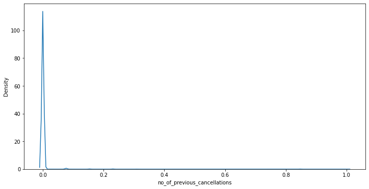

```python
plt.figure(figsize=(12, 6))
sns.kdeplot(data = hotel_data, x = 'no_of_previous_cancellations')
plt.show()
```

**Feature engineering complete on number of previous cancellations.**

**Perform feature engineering on number of previous bookings not canceled.**

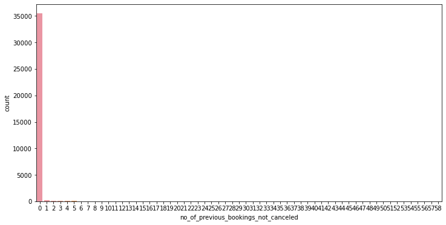

```python
plt.figure(figsize=(12, 6))
sns.countplot(data = hotel_data, x = 'no_of_previous_bookings_not_canceled')
plt.show()
```

**Perform minmax scaling from 0 to 1.**

```python
hotel_data['no_of_previous_bookings_not_canceled'] -= np.min(hotel_data['no_of_previous_bookings_not_canceled'])
hotel_data['no_of_previous_bookings_not_canceled'] /= np.max(hotel_data['no_of_previous_bookings_not_canceled'])
```

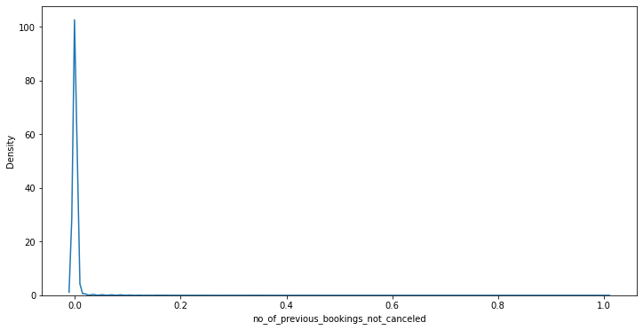

```python
plt.figure(figsize=(12, 6))
sns.kdeplot(data = hotel_data, x = 'no_of_previous_bookings_not_canceled')
plt.show()
```

**Feature engineering on number of previous bookings not canceled complete.**

**Perform feature engineering on average price per room.**

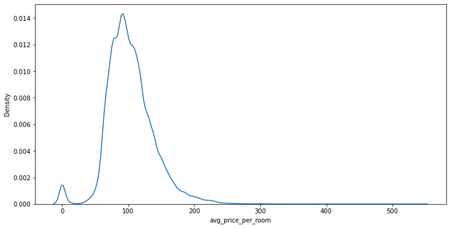

```python
plt.figure(figsize=(12, 6))
sns.kdeplot(data = hotel_data, x = 'avg_price_per_room')
plt.show()
```

**Perform minmax scaling and power scaling.**

```python
hotel_data['avg_price_per_room'] -= np.min(hotel_data['avg_price_per_room'])
hotel_data['avg_price_per_room'] /= np.max(hotel_data['avg_price_per_room'])
```

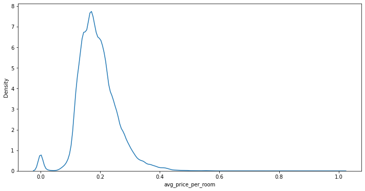

```python
plt.figure(figsize=(12, 6))
sns.kdeplot(data = hotel_data, x = 'avg_price_per_room')
plt.show()
```

**Perform power scaling.**

```python
hotel_data['avg_price_per_room'] = np.power(hotel_data['avg_price_per_room'], 5/12)
```

```python
hotel_data['avg_price_per_room'].describe()
```

```
count    36275.000000
mean         0.492138
std          0.088292
min          0.000000
25%          0.451995
50%          0.494126
75%          0.534353
max          1.000000
Name: avg_price_per_room, dtype: float64
```

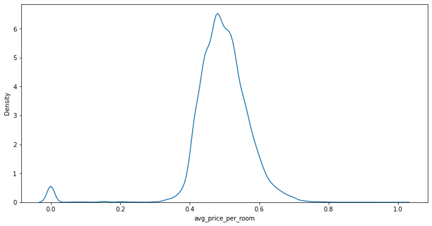

```python
plt.figure(figsize=(12, 6))
sns.kdeplot(data = hotel_data, x = 'avg_price_per_room')
plt.show()
```

**Feature engineering completer on average price per room.**

**Perform feature engineering on number of special requests.**

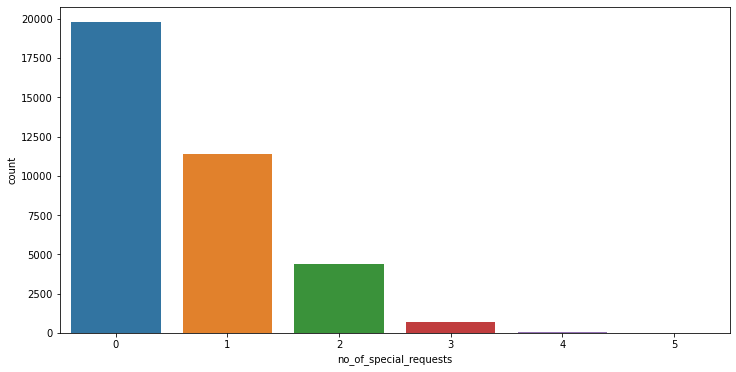

```python
plt.figure(figsize=(12, 6))
sns.countplot(data = hotel_data, x = 'no_of_special_requests')
plt.show()
```

**Perform minmax scaling.**

```python
hotel_data['no_of_special_requests'] -= np.min(hotel_data['no_of_special_requests'])
hotel_data['no_of_special_requests'] /= np.max(hotel_data['no_of_special_requests'])
```

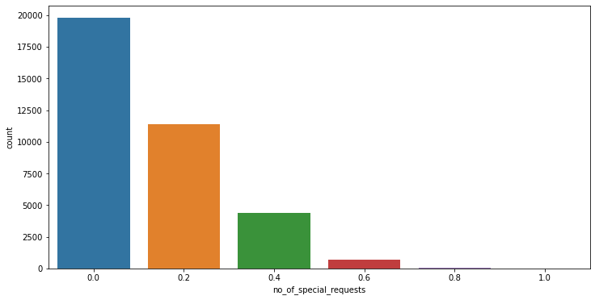

```python
plt.figure(figsize=(12, 6))
sns.countplot(data = hotel_data, x = 'no_of_special_requests')
plt.show()
```

**Feature engineering complete on number of special requests.**

**Perform feature engineering on booking status.**

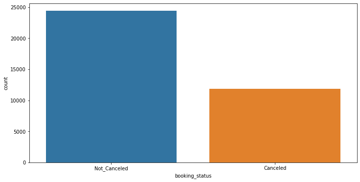

```python
plt.figure(figsize=(12, 6))
sns.countplot(data = hotel_data, x = 'booking_status')
plt.show()
```

**Convert categorical data to ordinal data.**

```python
hotel_data.loc[hotel_data['booking_status'] == 'Not_Canceled', 'booking_status'] = 0
hotel_data.loc[hotel_data['booking_status'] == 'Canceled', 'booking_status'] = 1
```

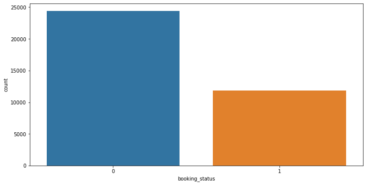

```python
plt.figure(figsize=(12, 6))
sns.countplot(data = hotel_data, x = 'booking_status')
plt.show()
```

**Feature engineering complete on all features.**

## EDA

- It is a good idea to explore the data once again after manipulating it.

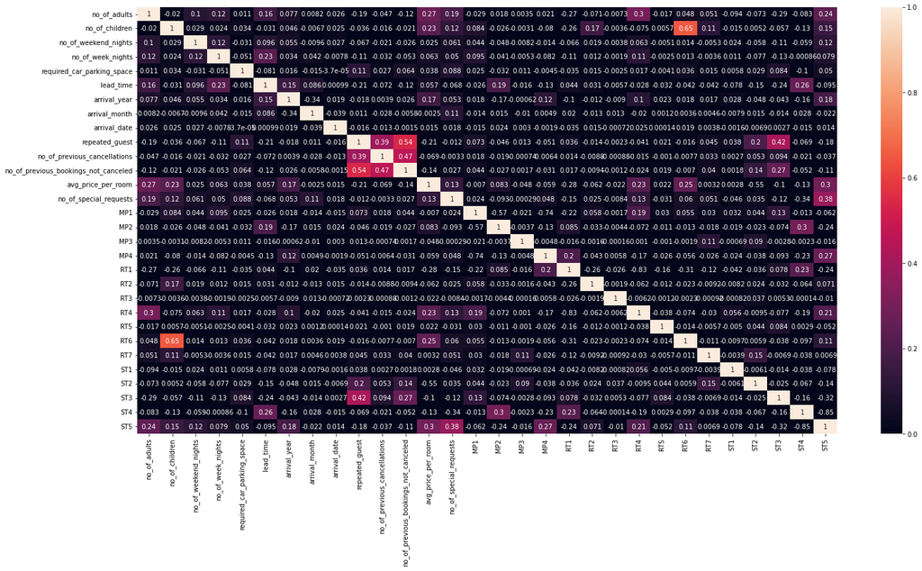

```python
plt.figure(figsize=(24, 12))
ax = sns.heatmap(data = hotel_data.corr(), vmin = 0, vmax = 1, annot = True)
```

**Calculate the impurity of the dataset.**

**Entropy impurity**

```python
def compute_impurity(feature, impurity_criterion):
    probs = feature.value_counts(normalize = True)
    if impurity_criterion == 'entropy':
        impurity = -1 * np.sum(np.log2(probs) * probs)
    elif impurity_criterion == 'gini':
        impurity = 1 - np.sum(np.square(probs))
    return(impurity)
```

```python
impurity_list = []
for column in hotel_data.columns:
    impurity = compute_impurity(hotel_data[column], 'entropy')
    impurity_list.append([column, impurity])
impurity_array = np.array(impurity_list, dtype = str)
impurity_df = pd.DataFrame(impurity_array, columns = ['feature', 'impurity'])
impurity_df['impurity'] = impurity_df['impurity'].astype(float)
impurity_df = impurity_df.sort_values(by = ['impurity'], axis = 0, inplace = False)
print(impurity_df)
```

```
                                 feature  impurity
17                                   MP3  0.001967
21                                   RT3  0.002659
26                                   ST1  0.033153
25                                   RT7  0.040431
23                                   RT5  0.062345
27                                   ST2  0.085913
10          no_of_previous_cancellations  0.094047
20                                   RT2  0.136223
9                         repeated_guest  0.172018
24                                   RT6  0.177199
4             required_car_parking_space  0.199310
11  no_of_previous_bookings_not_canceled  0.241882
28                                   ST3  0.309737
16                                   MP2  0.440163
```

[output cut: 17 more lines]

**Entropy impurity is a measure of disorder in the dataset.**  
**A lower entropy impurity value signifies a low degree of disorder.**  
**A high entropy impurity value signifies a high degree of disorder.**

```python
impurity_list = []
for column in hotel_data.columns:
    impurity = compute_impurity(hotel_data[column], 'gini')
    impurity_list.append([column, impurity])
impurity_array = np.array(impurity_list, dtype = str)
impurity_df = pd.DataFrame(impurity_array, columns = ['feature', 'impurity'])
impurity_df['impurity'] = impurity_df['impurity'].astype(float)
impurity_df = impurity_df.sort_values(by = ['impurity'], axis = 0, inplace = False)
print(impurity_df)
```

```
                                 feature  impurity
17                                   MP3  0.000276
21                                   RT3  0.000386
26                                   ST1  0.006868
25                                   RT7  0.008673
23                                   RT5  0.014504
10          no_of_previous_cancellations  0.018515
27                                   ST2  0.021325
20                                   RT2  0.037425
11  no_of_previous_bookings_not_canceled  0.044205
9                         repeated_guest  0.049960
24                                   RT6  0.051842
4             required_car_parking_space  0.060051
28                                   ST3  0.105023
1                         no_of_children  0.140380
```

[output cut: 17 more lines]

**Gini impurity is a measure of disorder in the dataset.**  
**A lower gini impurity value signifies a low degree of disorder.**  
**A high gini impurity value signifies a high degree of disorder.**

**Calculate mutual information**

```python
from pandas.api.types import is_numeric_dtype
```

```python
from sklearn.feature_selection import mutual_info_regression

def information_gain(
    df,
    labels : str,
    predictors : list,
    rdm_seed : int = 1234
) -> any:
    '''
    information_gain():
        Get most important features based on the value of information gain for categorical target variable.

        Parameters
        ----------
        df : pd.DataFrame, required
            Input dataframe containing all features
        predictors : list of str, required
            List of predictor features
        labels : list, required
            Target feature
        rdm_seed : random seed, not required
            Random seed used for reproducibility

        Returns
        ------
        important_features : pd.Dataframe
            Dataframe containing feature name and information gain value
    '''
    df_predictors = df[predictors]
    df_target = df[labels]

    importances = mutual_info_regression(df_predictors, df_target, random_state = rdm_seed, discrete_features = True)
    high_score_features = []
    for score, f_name in sorted(zip(importances, df_predictors.columns), reverse = True):
        high_score_features.append({'Feature': f_name, 'Score': score})

    df_important_features = pd.DataFrame(high_score_features)
    return df_important_features
```

```python
target = 'booking_status'
features = list(hotel_data.columns)
features.remove(target)

df_mutual_information = information_gain(
    hotel_data,
    target,
    features,
    1234
)
```

```python
print(df_mutual_information)
```

```
                                 Feature     Score
0                     avg_price_per_room  0.191280
1                              lead_time  0.138821
2                 no_of_special_requests  0.040838
3                           arrival_year  0.021561
4                          arrival_month  0.020249
5                                    ST3  0.010654
6                      no_of_week_nights  0.010389
7                         repeated_guest  0.010310
8   no_of_previous_bookings_not_canceled  0.010189
9                                    MP2  0.008173
10            required_car_parking_space  0.007724
11                          no_of_adults  0.007606
12                                   ST5  0.007473
13                                   ST2  0.006203
```

[output cut: 16 more lines]

## Checking Multicollinearity

- In order to make statistical inferences from a logistic regression model, it is important to ensure that there is no multicollinearity present in the data.

**Calculate variance inflation factor.**

```python
from statsmodels.stats.outliers_influence import variance_inflation_factor
```

```python
target = 'booking_status'
features = list(hotel_data.columns)
features.remove(target)
```

```python
df_vif = hotel_data.copy()[features]
```

```python
vif = [
    [val, variance_inflation_factor(df_vif.values, i)]
    for i, val
    in zip(np.arange(0, len(df_vif.columns)), df_vif.columns.values)
]
```

```python
vif_score_df = pd.DataFrame(vif, columns = ['Feature', 'VIF']).sort_values(by = 'VIF')
```

```python
print(vif_score_df)
```

```
                                 Feature       VIF
8                           arrival_date  1.006030
4             required_car_parking_space  1.035752
2                   no_of_weekend_nights  1.050907
3                      no_of_week_nights  1.109111
7                          arrival_month  1.210103
13                no_of_special_requests  1.247866
0                           no_of_adults  1.345108
10          no_of_previous_cancellations  1.350972
6                           arrival_year  1.375902
5                              lead_time  1.408786
11  no_of_previous_bookings_not_canceled  1.614254
9                         repeated_guest  1.769537
1                         no_of_children  1.984389
12                    avg_price_per_room  2.140017
```

[output cut: 16 more lines]

**All one hot encoded features have a high degree of multicolinearity.**  
**Drop these features one at a time to see if the multicolinearity can be reduced.**

```python
target = 'booking_status'
features = list(hotel_data.columns)
features.remove(target)
features.remove('RT1')
```

```python
df_vif = hotel_data.copy()[features]
```

```python
vif = [
    [val, variance_inflation_factor(df_vif.values, i)]
    for i, val
    in zip(np.arange(0, len(df_vif.columns)), df_vif.columns.values)
]
```

```python
vif_score_df = pd.DataFrame(vif, columns = ['Feature', 'VIF']).sort_values(by = 'VIF')
```

```python
print(vif_score_df)
```

```
                                 Feature       VIF
19                                   RT3  1.002074
8                           arrival_date  1.006030
21                                   RT5  1.024250
4             required_car_parking_space  1.035752
2                   no_of_weekend_nights  1.050907
23                                   RT7  1.087297
18                                   RT2  1.092801
3                      no_of_week_nights  1.109111
7                          arrival_month  1.210103
13                no_of_special_requests  1.247866
20                                   RT4  1.326165
0                           no_of_adults  1.345108
10          no_of_previous_cancellations  1.350972
6                           arrival_year  1.375902
5                              lead_time  1.408786
11  no_of_previous_bookings_not_canceled  1.614254
9                         repeated_guest  1.769537
22                                   RT6  1.913174
1                         no_of_children  1.984389
12                    avg_price_per_room  2.140017
24                                   ST1       inf
26                                   ST3       inf
25                                   ST2       inf
14                                   MP1       inf
16                                   MP3       inf
15                                   MP2       inf
27                                   ST4       inf
17                                   MP4       inf
28                                   ST5       inf
```

**Scores improved. Remove another feature.**

```python
target = 'booking_status'
features = list(hotel_data.columns)
features.remove(target)
features.remove('RT1')
features.remove('ST1')
```

```python
df_vif = hotel_data.copy()[features]
```

```python
vif = [
    [val, variance_inflation_factor(df_vif.values, i)]
    for i, val
    in zip(np.arange(0, len(df_vif.columns)), df_vif.columns.values)
]
```

```python
vif_score_df = pd.DataFrame(vif, columns = ['Feature', 'VIF']).sort_values(by = 'VIF')
```

```python
print(vif_score_df)
```

```
                                 Feature         VIF
19                                   RT3    1.002074
8                           arrival_date    1.006030
21                                   RT5    1.024250
4             required_car_parking_space    1.035752
2                   no_of_weekend_nights    1.050907
16                                   MP3    1.067423
23                                   RT7    1.087297
18                                   RT2    1.092801
3                      no_of_week_nights    1.109111
7                          arrival_month    1.210103
13                no_of_special_requests    1.247866
20                                   RT4    1.326165
0                           no_of_adults    1.345108
10          no_of_previous_cancellations    1.350972
6                           arrival_year    1.375902
5                              lead_time    1.408786
11  no_of_previous_bookings_not_canceled    1.614254
9                         repeated_guest    1.769537
22                                   RT6    1.913174
1                         no_of_children    1.984389
12                    avg_price_per_room    2.140017
24                                   ST2    4.880551
25                                   ST3   16.556460
15                                   MP2   35.342434
17                                   MP4   52.471963
26                                   ST4   62.768280
27                                   ST5   69.529891
14                                   MP1  281.616066
```

**Scores improved. Remove another feature.**

```python
target = 'booking_status'
features = list(hotel_data.columns)
features.remove(target)
features.remove('RT1')
features.remove('ST1')
features.remove('MP1')
```

```python
df_vif = hotel_data.copy()[features]
```

```python
vif = [
    [val, variance_inflation_factor(df_vif.values, i)]
    for i, val
    in zip(np.arange(0, len(df_vif.columns)), df_vif.columns.values)
]
```

```python
vif_score_df = pd.DataFrame(vif, columns = ['Feature', 'VIF']).sort_values(by = 'VIF')
```

```python
print(vif_score_df)
```

```
                                 Feature        VIF
18                                   RT3   1.002264
15                                   MP3   1.018185
20                                   RT5   1.030255
4             required_car_parking_space   1.068865
22                                   RT7   1.089899
17                                   RT2   1.112338
14                                   MP2   1.326885
23                                   ST2   1.327800
10          no_of_previous_cancellations   1.356401
16                                   MP4   1.466146
19                                   RT4   1.589236
11  no_of_previous_bookings_not_canceled   1.626201
9                         repeated_guest   1.804555
2                   no_of_weekend_nights   1.950420
21                                   RT6   1.955394
13                no_of_special_requests   2.017682
1                         no_of_children   2.117879
8                           arrival_date   3.781869
24                                   ST3   4.225349
3                      no_of_week_nights   4.230653
7                          arrival_month   4.344319
6                           arrival_year   7.601814
5                              lead_time   8.482304
0                           no_of_adults  18.352755
25                                   ST4  19.476544
26                                   ST5  46.028986
12                    avg_price_per_room  59.126589
```

**Scores improved. Remove another feature.**

```python
target = 'booking_status'
features = list(hotel_data.columns)
features.remove(target)
features.remove('RT1')
features.remove('ST1')
features.remove('MP1')
features.remove('avg_price_per_room')
```

```python
df_vif = hotel_data.copy()[features]
```

```python
vif = [
    [val, variance_inflation_factor(df_vif.values, i)]
    for i, val
    in zip(np.arange(0, len(df_vif.columns)), df_vif.columns.values)
]
```

```python
vif_score_df = pd.DataFrame(vif, columns = ['Feature', 'VIF']).sort_values(by = 'VIF')
```

```python
print(vif_score_df)
```

```
                                 Feature        VIF
17                                   RT3   1.002239
14                                   MP3   1.018138
19                                   RT5   1.024438
4             required_car_parking_space   1.066360
21                                   RT7   1.082433
16                                   RT2   1.108946
13                                   MP2   1.279261
22                                   ST2   1.313389
10          no_of_previous_cancellations   1.356400
15                                   MP4   1.448912
18                                   RT4   1.533769
11  no_of_previous_bookings_not_canceled   1.624772
9                         repeated_guest   1.802389
20                                   RT6   1.903119
2                   no_of_weekend_nights   1.947154
12                no_of_special_requests   2.016196
1                         no_of_children   2.097343
23                                   ST3   2.338153
8                           arrival_date   3.779574
3                      no_of_week_nights   4.230351
7                          arrival_month   4.264785
6                           arrival_year   7.128547
5                              lead_time   8.391682
24                                   ST4   9.550978
0                           no_of_adults  17.729014
25                                   ST5  21.513209
```

**Scores improved. Two feature remaining with a VIF > 10. Remove another feature.**

```python
target = 'booking_status'
features = list(hotel_data.columns)
features.remove(target)
features.remove('RT1')
features.remove('ST1')
features.remove('MP1')
features.remove('avg_price_per_room')
features.remove('ST5')
```

```python
df_vif = hotel_data.copy()[features]
```

```python
vif = [
    [val, variance_inflation_factor(df_vif.values, i)]
    for i, val
    in zip(np.arange(0, len(df_vif.columns)), df_vif.columns.values)
]
```

```python
vif_score_df = pd.DataFrame(vif, columns = ['Feature', 'VIF']).sort_values(by = 'VIF')
```

```python
print(vif_score_df)
```

```
                                 Feature        VIF
17                                   RT3   1.002239
14                                   MP3   1.018137
19                                   RT5   1.024186
4             required_car_parking_space   1.065620
21                                   RT7   1.079668
16                                   RT2   1.102690
22                                   ST2   1.121960
13                                   MP2   1.276391
10          no_of_previous_cancellations   1.355292
15                                   MP4   1.419493
23                                   ST3   1.431148
18                                   RT4   1.523083
11  no_of_previous_bookings_not_canceled   1.623762
9                         repeated_guest   1.799797
20                                   RT6   1.900804
2                   no_of_weekend_nights   1.935736
12                no_of_special_requests   2.002407
24                                   ST4   2.022999
1                         no_of_children   2.081971
8                           arrival_date   3.531152
7                          arrival_month   3.765043
3                      no_of_week_nights   4.088843
6                           arrival_year   6.091547
5                              lead_time   8.197945
0                           no_of_adults  11.530901
```

**A VIF score of 11.5 is acceptable for the sake if this analysis.**  
**The above features will be used to train the initial model.**

## Building a Logistic Regression model

```python
target = 'booking_status'
features_to_drop = ['RT1', 'ST1', 'MP1', 'ST5', 'avg_price_per_room', target]
X = hotel_data.drop(features_to_drop, axis=1).astype(float)
Y = hotel_data[target].astype(float)

# adding constant
X = sm.add_constant(X)

# splitting in training and test set
X_train, X_test, y_train, y_test = train_test_split(X, Y, test_size=0.3, random_state=1)
```

```python
logit = sm.Logit(y_train, X_train)
lg = logit.fit(
    disp=False,
    method='basinhopping'
)

print(lg.summary())
```

```
                           Logit Regression Results
==============================================================================
Dep. Variable:         booking_status   No. Observations:                25392
Model:                          Logit   Df Residuals:                    25366
Method:                           MLE   Df Model:                           25
Date:                Fri, 03 Jun 2022   Pseudo R-squ.:                  0.3031
Time:                        19:17:41   Log-Likelihood:                -11214.
converged:                       True   LL-Null:                       -16091.
Covariance Type:            nonrobust   LLR p-value:                     0.000
========================================================================================================
                                           coef    std err          z      P>|z|      [0.025      0.975]
--------------------------------------------------------------------------------------------------------
const                                   -3.7224      0.108    -34.621      0.000      -3.933      -3.512
no_of_adults                             0.8563      0.146      5.865      0.000       0.570       1.143
no_of_children                           3.1101      0.568      5.479      0.000       1.998       4.223
no_of_weekend_nights                     0.1854      0.133      1.392      0.164      -0.076       0.446
no_of_week_nights                       -0.2464      0.080     -3.083      0.002      -0.403      -0.090
required_car_parking_space              -1.3681      0.137     -9.996      0.000      -1.636      -1.100
lead_time                                5.9261      0.105     56.215      0.000       5.720       6.133
arrival_year                             0.9239      0.057     16.145      0.000       0.812       1.036
arrival_month                           -0.0410      0.060     -0.679      0.497      -0.159       0.077
arrival_date                             0.0276      0.057      0.486      0.627      -0.084       0.139
repeated_guest                          -2.1424      0.566     -3.786      0.000      -3.252      -1.033
no_of_previous_cancellations             3.4948      1.177      2.969      0.003       1.187       5.802
no_of_previous_bookings_not_canceled   -11.4732      9.122     -1.258      0.209     -29.353       6.406
no_of_special_requests                  -7.2208      0.149    -48.589      0.000      -7.512      -6.930
MP2                                      0.7446      0.059     12.623      0.000       0.629       0.860
MP3                                     10.3572     42.904      0.241      0.809     -73.732      94.447
MP4                                      0.0632      0.053      1.197      0.231      -0.040       0.167
RT2                                     -0.5453      0.125     -4.352      0.000      -0.791      -0.300
RT3                                     -0.1788      1.305     -0.137      0.891      -2.736       2.378
RT4                                      0.0230      0.050      0.458      0.647      -0.075       0.121
RT5                                     -0.1766      0.212     -0.832      0.405      -0.593       0.239
RT6                                      0.2865      0.141      2.037      0.042       0.011       0.562
RT7                                      0.3163      0.277      1.144      0.253      -0.226       0.858
ST2                                    -14.0646     43.566     -0.323      0.747     -99.452      71.323
ST3                                     -0.9193      0.105     -8.779      0.000      -1.125      -0.714
ST4                                     -1.8772      0.048    -38.744      0.000      -1.972      -1.782
========================================================================================================
```

## Observations

- If the coefficient is negative, then that means that if the value of that feature increases, it is less likely to lead to a canceled booking status.
- If the coefficient is positive, it is more likely to lead to a canceled booking status.
- A p-value less than 0.05 (5%) is said to be significant.
- no_of_weekend_nights, arrival_month, arrival_date, no_of_previous_bookings_not_canceled, MP3, MP4, RT3, RT4, RT5, RT7, and ST2 have low significance. These features can be removed.

**Remove features with a low significance level.**

```python
target = 'booking_status'
features_to_drop = [
    'RT1', 'ST1', 'MP1', 'ST5', 'avg_price_per_room',
    'no_of_weekend_nights', 'arrival_month', 'arrival_date', 'no_of_previous_bookings_not_canceled',
    'MP3', 'MP4', 'RT3', 'RT4', 'RT5', 'RT7', 'ST2',
    target
]
X = hotel_data.drop(features_to_drop, axis=1).astype(float)
Y = hotel_data[target].astype(float)

# adding constant
X = sm.add_constant(X)

# splitting in training and test set
X_train, X_test, y_train, y_test = train_test_split(X, Y, test_size=0.3, random_state=1)
```

```python
logit = sm.Logit(y_train, X_train)
lg = logit.fit(
    disp=False,
    method='basinhopping'
)

print(lg.summary())
```

```
                           Logit Regression Results
==============================================================================
Dep. Variable:         booking_status   No. Observations:                25392
Model:                          Logit   Df Residuals:                    25377
Method:                           MLE   Df Model:                           14
Date:                Fri, 03 Jun 2022   Pseudo R-squ.:                  0.3007
Time:                        19:18:06   Log-Likelihood:                -11253.
converged:                       True   LL-Null:                       -16091.
Covariance Type:            nonrobust   LLR p-value:                     0.000
================================================================================================
                                   coef    std err          z      P>|z|      [0.025      0.975]
------------------------------------------------------------------------------------------------
const                           -3.7511      0.096    -39.085      0.000      -3.939      -3.563
no_of_adults                     0.9243      0.140      6.617      0.000       0.651       1.198
no_of_children                   3.1494      0.551      5.712      0.000       2.069       4.230
no_of_week_nights               -0.2298      0.079     -2.908      0.004      -0.385      -0.075
required_car_parking_space      -1.3624      0.136     -9.983      0.000      -1.630      -1.095
lead_time                        5.9274      0.103     57.656      0.000       5.726       6.129
arrival_year                     0.9438      0.054     17.535      0.000       0.838       1.049
repeated_guest                  -2.7326      0.482     -5.668      0.000      -3.678      -1.788
no_of_previous_cancellations     3.1654      1.017      3.114      0.002       1.173       5.158
no_of_special_requests          -7.2144      0.147    -49.104      0.000      -7.502      -6.926
MP2                              0.7390      0.059     12.587      0.000       0.624       0.854
RT2                             -0.5516      0.124     -4.442      0.000      -0.795      -0.308
RT6                              0.2674      0.138      1.939      0.053      -0.003       0.538
ST3                             -0.9386      0.103     -9.128      0.000      -1.140      -0.737
ST4                             -1.8852      0.046    -40.653      0.000      -1.976      -1.794
================================================================================================
```

```python
# converting coefficients to odds
odds = np.exp(lg.params)

# finding the percentage change
perc_change_odds = (np.exp(lg.params) - 1) * 100

# removing limit from number of columns to display
pd.set_option("display.max_columns", None)

# adding the odds to a dataframe
pd.DataFrame({"Odds": odds, "Change_odd%": perc_change_odds}, index=X_train.columns).T
```

|  | const | no_of_adults | no_of_children | no_of_week_nights | required_car_parking_space | lead_time | arrival_year | repeated_guest | no_of_previous_cancellations | no_of_special_requests | MP2 | RT2 | RT6 | ST3 | ST4 |
| --- | --- | --- | --- | --- | --- | --- | --- | --- | --- | --- | --- | --- | --- | --- | --- |
| Odds | 0.023492 | 2.520077 | 23.322075 | 0.794685 | 0.256051 | 375.193883 | 2.569723 | 0.065052 | 23.697989 | 0.000736 | 2.093909 | 0.576024 | 1.306502 | 0.391185 | 0.151799 |
| Change_odd% | -97.650773 | 152.007673 | 2232.207522 | -20.531457 | -74.394917 | 37419.388322 | 156.972251 | -93.494782 | 2269.798867 | -99.926407 | 109.390889 | -42.397568 | 30.650230 | -60.881516 | -84.820077 |

## Model performance evaluation

```python
def confusion_matrix_statsmodels(model, predictors, target, threshold=0.5):
    """
    To plot the confusion_matrix with percentages

    model: classifier
    predictors: independent variables
    target: dependent variable
    threshold: threshold for classifying the observation as class 1
    """
    y_pred = model.predict(predictors) > threshold
    cm = confusion_matrix(target, y_pred)
    labels = np.asarray(
        [
            ["{0:0.0f}".format(item) + "\n{0:.2%}".format(item / cm.flatten().sum())]
            for item in cm.flatten()
        ]
    ).reshape(2, 2)

    plt.figure(figsize=(20, 12))
    sns.heatmap(cm, annot=labels, fmt="")
    plt.ylabel("True label")
    plt.xlabel("Predicted label")
```

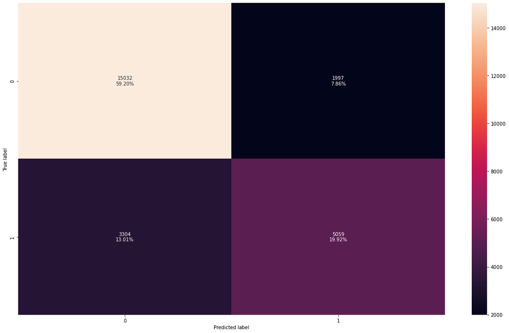

```python
# creating confusion matrix
confusion_matrix_statsmodels(lg, X_train, y_train)
```

```python
def model_performance_classification_statsmodels(
    model, predictors, target, threshold=0.5
):
    """
    Function to compute different metrics to check classification model performance

    model: classifier
    predictors: independent variables
    target: dependent variable
    threshold: threshold for classifying the observation as class 1
    """

    # checking which probabilities are greater than threshold
    pred_temp = model.predict(predictors) > threshold
    # rounding off the above values to get classes
    pred = np.round(pred_temp)

    acc = accuracy_score(target, pred)  # to compute Accuracy
    recall = recall_score(target, pred)  # to compute Recall
    precision = precision_score(target, pred)  # to compute Precision
    f1 = f1_score(target, pred)  # to compute F1-score

    # creating a dataframe of metrics
    df_perf = pd.DataFrame(
        {"Accuracy": acc, "Recall": recall, "Precision": precision, "F1": f1,},
        index=[0],
    )

    return df_perf
```

```python
log_reg_model_train_perf = model_performance_classification_statsmodels(
    lg, X_train, y_train
)

print("Training performance:")
log_reg_model_train_perf
```

```
Training performance:
```

|  | Accuracy | Recall | Precision | F1 |
| --- | --- | --- | --- | --- |
| 0 | 0.791233 | 0.604926 | 0.716978 | 0.656203 |

```python
log_reg_model_test_perf = model_performance_classification_statsmodels(
    lg, X_test, y_test
)

print("Testing performance:")
log_reg_model_test_perf
```

```
Testing performance:
```

|  | Accuracy | Recall | Precision | F1 |
| --- | --- | --- | --- | --- |
| 0 | 0.795369 | 0.607893 | 0.716773 | 0.657858 |

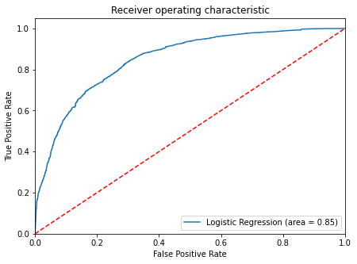

```python
logit_roc_auc_train = roc_auc_score(y_train, lg.predict(X_train))
fpr, tpr, thresholds = roc_curve(y_train, lg.predict(X_train))
plt.figure(figsize=(7, 5))
plt.plot(fpr, tpr, label="Logistic Regression (area = %0.2f)" % logit_roc_auc_train)
plt.plot([0, 1], [0, 1], "r--")
plt.xlim([0.0, 1.0])
plt.ylim([0.0, 1.05])
plt.xlabel("False Positive Rate")
plt.ylabel("True Positive Rate")
plt.title("Receiver operating characteristic")
plt.legend(loc="lower right")
plt.show()
```

**Let's try to improve the performance of the model by changing the threshold in the ROC-AUC curve.**

**Get the optimal threshold from the ROC-AUC curve.**

```python
# Optimal threshold as per AUC-ROC curve
# The optimal cut off would be where tpr is high and fpr is low
fpr, tpr, thresholds = roc_curve(y_train, lg.predict(X_train))

optimal_idx = np.argmax(tpr - fpr)
optimal_threshold_auc_roc = thresholds[optimal_idx]
print(optimal_threshold_auc_roc)
```

```
0.2855862531786229
```

**Get model performance of training set using this new threshold.**

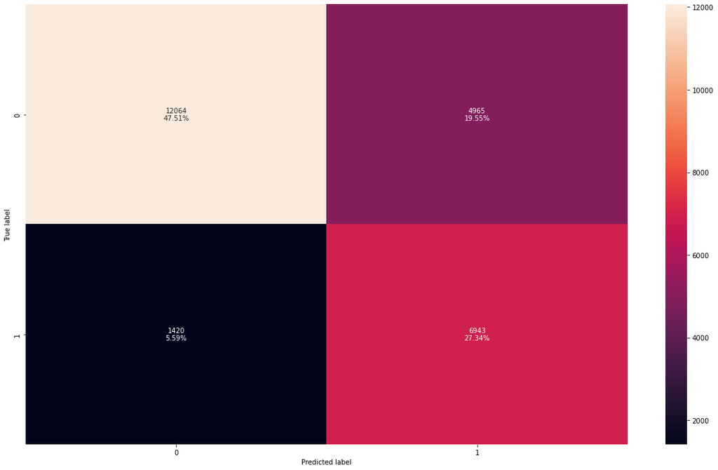

```python
confusion_matrix_statsmodels(
    lg, X_train, y_train, threshold = optimal_threshold_auc_roc
)
```

```python
log_reg_model_train_perf_threshold_auc_roc = model_performance_classification_statsmodels(
    lg, X_train, y_train, threshold = optimal_threshold_auc_roc
)
print("Training performance:")
log_reg_model_train_perf_threshold_auc_roc
```

```
Training performance:
```

|  | Accuracy | Recall | Precision | F1 |
| --- | --- | --- | --- | --- |
| 0 | 0.748543 | 0.830204 | 0.583053 | 0.685018 |

## Obervations

- Overall accuracy has reduced for the model. The accuracy dropped from 79% to 75%.
- However, the Recall of the model has improved substantually, going from 60.7% to 83%.
- This means that cancellations will be caught 83% of the time.
- Nonetheless, the precision has reduced for the model, dropping from 71.7% to 58%.
- This means that more customers who won't cancel will be predicted to cancel.
- The F1-score improved, going from 65.6% to 68.5%. F1-score is considered a better metric than accuracy for imbalanced datasets.

```python
log_reg_model_test_perf_threshold_auc_roc = model_performance_classification_statsmodels(
    lg, X_test, y_test, threshold = optimal_threshold_auc_roc
)
print("Testing performance:")
log_reg_model_test_perf_threshold_auc_roc
```

```
Testing performance:
```

|  | Accuracy | Recall | Precision | F1 |
| --- | --- | --- | --- | --- |
| 0 | 0.75108 | 0.829358 | 0.580831 | 0.683195 |

**Test performance is comparable to training performance, meaning that the model is optimally fit.**

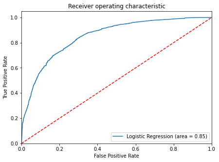

```python
logit_roc_auc_train = roc_auc_score(y_train, lg.predict(X_train))
fpr, tpr, thresholds = roc_curve(y_train, lg.predict(X_train))
plt.figure(figsize=(7, 5))
plt.plot(fpr, tpr, label="Logistic Regression (area = %0.2f)" % logit_roc_auc_train)
plt.plot([0, 1], [0, 1], "r--")
plt.xlim([0.0, 1.0])
plt.ylim([0.0, 1.05])
plt.xlabel("False Positive Rate")
plt.ylabel("True Positive Rate")
plt.title("Receiver operating characteristic")
plt.legend(loc="lower right")
plt.show()
```

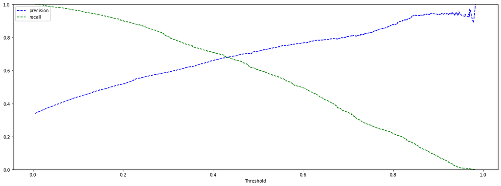

```python
y_scores = lg.predict(X_train)
prec, rec, tre = precision_recall_curve(y_train, y_scores,)


def plot_prec_recall_vs_tresh(precisions, recalls, thresholds):
    plt.plot(thresholds, precisions[:-1], "b--", label="precision")
    plt.plot(thresholds, recalls[:-1], "g--", label="recall")
    plt.xlabel("Threshold")
    plt.legend(loc="upper left")
    plt.ylim([0, 1])


plt.figure(figsize=(20, 7))
plot_prec_recall_vs_tresh(prec, rec, tre)
plt.show()
```

## Observations

- Using a threshold of approximately 0.45 would get equal precision and recall.
- Setting a lower threshold would get a higher recall.

```python
optimal_threshold_curve = 0.45
```

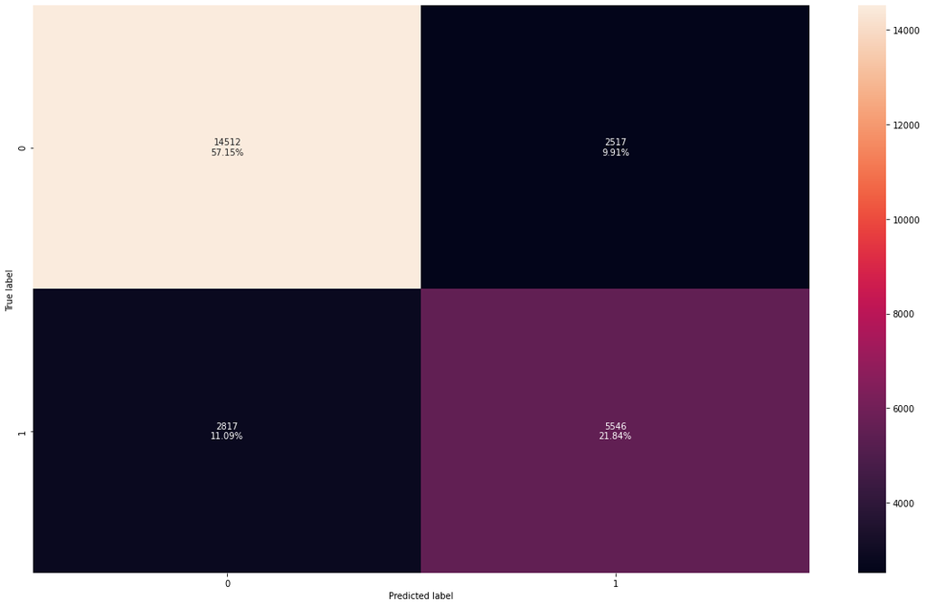

```python
confusion_matrix_statsmodels(lg, X_train, y_train, threshold = optimal_threshold_curve)
```

```python
log_reg_model_train_perf_threshold_curve = model_performance_classification_statsmodels(
    lg, X_train, y_train, threshold = optimal_threshold_curve
)
print("Training performance:")
log_reg_model_train_perf_threshold_curve
```

```
Training performance:
```

|  | Accuracy | Recall | Precision | F1 |
| --- | --- | --- | --- | --- |
| 0 | 0.789934 | 0.663159 | 0.687833 | 0.675271 |

```python
log_reg_model_test_perf_threshold_curve = model_performance_classification_statsmodels(
    lg, X_test, y_test, threshold = optimal_threshold_curve
)
print("Testing performance:")
log_reg_model_test_perf_threshold_curve
```

```
Testing performance:
```

|  | Accuracy | Recall | Precision | F1 |
| --- | --- | --- | --- | --- |
| 0 | 0.795461 | 0.674617 | 0.6875 | 0.680997 |

## Observations

- Model gives a higher F1 score than the initial model.
- Model gives a lower F1-score than the optimal Recall model.
- Model gives a lower accuracy than the initial model.
- Model gives a higher accuracy then the optimal Recall model.

## Comparison across all models

```python
# training performance comparison
models_train_comp_df = pd.concat(
    [
        log_reg_model_train_perf.T,
        log_reg_model_train_perf_threshold_auc_roc.T,
        log_reg_model_train_perf_threshold_curve.T,
    ],
    axis=1,
)
models_train_comp_df.columns = [
    "Logistic Regression statsmodel",
    "Logistic Regression-0.28 Threshold",
    "Logistic Regression-0.45 Threshold",
]

print("Training performance comparison:")
models_train_comp_df
```

```
Training performance comparison:
```

|  | Logistic Regression statsmodel | Logistic Regression-0.28 Threshold | Logistic Regression-0.45 Threshold |
| --- | --- | --- | --- |
| Accuracy | 0.791233 | 0.748543 | 0.789934 |
| Recall | 0.604926 | 0.830204 | 0.663159 |
| Precision | 0.716978 | 0.583053 | 0.687833 |
| F1 | 0.656203 | 0.685018 | 0.675271 |

# Obervations

- 0.28 and 0.45 threshold should be selected based on the intended use of the model.
- An expected value framework should be used to derive the threshold that corresponds to highest business value.

```python
# testing performance comparison
models_test_comp_df = pd.concat(
    [
        log_reg_model_test_perf.T,
        log_reg_model_test_perf_threshold_auc_roc.T,
        log_reg_model_test_perf_threshold_curve.T,
    ],
    axis=1,
)
models_test_comp_df.columns = [
    "Logistic Regression statsmodel",
    "Logistic Regression-0.28 Threshold",
    "Logistic Regression-0.45 Threshold",
]

print("Testing performance comparison:")
models_test_comp_df
```

```
Testing performance comparison:
```

|  | Logistic Regression statsmodel | Logistic Regression-0.28 Threshold | Logistic Regression-0.45 Threshold |
| --- | --- | --- | --- |
| Accuracy | 0.795369 | 0.751080 | 0.795461 |
| Recall | 0.607893 | 0.829358 | 0.674617 |
| Precision | 0.716773 | 0.580831 | 0.687500 |
| F1 | 0.657858 | 0.683195 | 0.680997 |

## Building a Decision Tree model

```python
def model_performance_classification_sklearn(model, predictors, target):
    """
    Function to compute different metrics to check classification model performance

    model: classifier
    predictors: independent variables
    target: dependent variable
    """

    # predicting using the independent variables
    pred = model.predict(predictors)

    acc = accuracy_score(target, pred)  # to compute Accuracy
    recall = recall_score(target, pred)  # to compute Recall
    precision = precision_score(target, pred)  # to compute Precision
    f1 = f1_score(target, pred)  # to compute F1-score

    # creating a dataframe of metrics
    df_perf = pd.DataFrame(
        {"Accuracy": acc, "Recall": recall, "Precision": precision, "F1": f1,},
        index=[0],
    )

    return df_perf
```

```python
def confusion_matrix_sklearn(model, predictors, target):
    """
    To plot the confusion_matrix with percentages

    model: classifier
    predictors: independent variables
    target: dependent variable
    """
    y_pred = model.predict(predictors)
    cm = confusion_matrix(target, y_pred)
    labels = np.asarray(
        [
            ["{0:0.0f}".format(item) + "\n{0:.2%}".format(item / cm.flatten().sum())]
            for item in cm.flatten()
        ]
    ).reshape(2, 2)

    plt.figure(figsize=(6, 4))
    sns.heatmap(cm, annot=labels, fmt="")
    plt.ylabel("True label")
    plt.xlabel("Predicted label")
```

```python
target = 'booking_status'
features_to_drop = [
    'RT1', 'ST1', 'MP1', 'ST5', 'avg_price_per_room',
    'no_of_weekend_nights', 'arrival_month', 'arrival_date', 'no_of_previous_bookings_not_canceled',
    'MP3', 'MP4', 'RT3', 'RT4', 'RT5', 'RT7', 'ST2',
    target
]
X = hotel_data.drop(features_to_drop, axis=1).astype(float)
Y = hotel_data[target].astype(float)

# splitting in training and test set
X_train, X_test, y_train, y_test = train_test_split(X, Y, test_size=0.3, random_state=1)
```

```python
model = DecisionTreeClassifier(criterion = 'gini', random_state = 1)
model.fit(X_train, y_train)
```

```
DecisionTreeClassifier(random_state=1)
```

```python
decision_tree_perf_train = model_performance_classification_sklearn(
    model, X_train, y_train
)
decision_tree_perf_train
```

|  | Accuracy | Recall | Precision | F1 |
| --- | --- | --- | --- | --- |
| 0 | 0.927339 | 0.831759 | 0.940763 | 0.882909 |

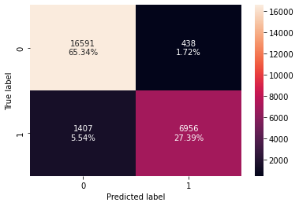

```python
confusion_matrix_sklearn(model, X_train, y_train)
```

```python
decision_tree_perf_test = model_performance_classification_sklearn(
    model, X_test, y_test
)
decision_tree_perf_test
```

|  | Accuracy | Recall | Precision | F1 |
| --- | --- | --- | --- | --- |
| 0 | 0.845631 | 0.724872 | 0.782169 | 0.752431 |

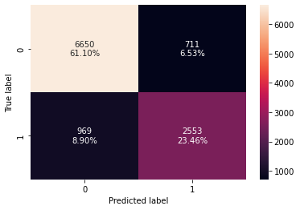

```python
confusion_matrix_sklearn(model, X_test, y_test)
```

**The model performs significantly better on the training set, meaning that it is overfitting.**  
**To decrease this overfitting, pre-pruning will need to be applied to the model.**

## Do we need to prune the tree?

**Yes, the model needs to be pre-pruned.**

## Pre-prune the tree

- Perform a grid search to set the optimal pre-pruning parameters.

```python
# Choose the type of classifier.
estimator = DecisionTreeClassifier(random_state=1)

# Grid of parameters to choose from

parameters = {
    "max_depth": [np.arange(2, 50, 5), None],
    "criterion": ["entropy", "gini"],
    "splitter": ["best", "random"],
    "min_impurity_decrease": [0.000001, 0.00001, 0.0001, 0.001, 0.01, 0.1],
}

# Type of scoring used to compare parameter combinations
acc_scorer = make_scorer(recall_score)

# Run the grid search
grid_obj = GridSearchCV(estimator, parameters, scoring=acc_scorer, cv=5)
grid_obj = grid_obj.fit(X_train, y_train)

# Set the clf to the best combination of parameters
estimator = grid_obj.best_estimator_

# Fit the best algorithm to the data.
estimator.fit(X_train, y_train)
```

```
DecisionTreeClassifier(min_impurity_decrease=0.0001, random_state=1)
```

**GridSearch() Model Performance on the training set.**

```python
decision_tree_tune_perf_train = model_performance_classification_sklearn(
    estimator, X_train, y_train
)
decision_tree_tune_perf_train
```

|  | Accuracy | Recall | Precision | F1 |
| --- | --- | --- | --- | --- |
| 0 | 0.854718 | 0.777592 | 0.780485 | 0.779036 |

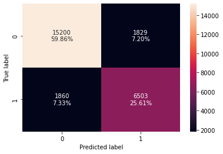

```python
confusion_matrix_sklearn(estimator, X_train, y_train)
```

**GridSearch() Model Performance on the test set.**

```python
decision_tree_tune_perf_test = model_performance_classification_sklearn(
    estimator, X_test, y_test
)

decision_tree_tune_perf_test
```

|  | Accuracy | Recall | Precision | F1 |
| --- | --- | --- | --- | --- |
| 0 | 0.847101 | 0.77314 | 0.758919 | 0.765963 |

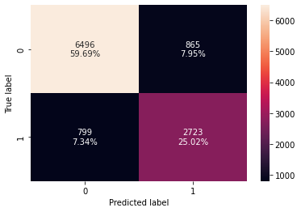

```python
confusion_matrix_sklearn(estimator, X_test, y_test)
```

## Observations

- The decision tree is optimally fit on the dataset since the training accuracy is comparable to the test accuracy.
- The GridSearch model outperformed the base model slightly on the test set with a higher recall and F1-score.
- However, the base model performed better on precision than the GridSearch model.
- Nevertheless, this pre-pruning procedure has created a more robust model that can handle future changes in the data.

```python
column_names = list(X.columns)
feature_names = column_names
```

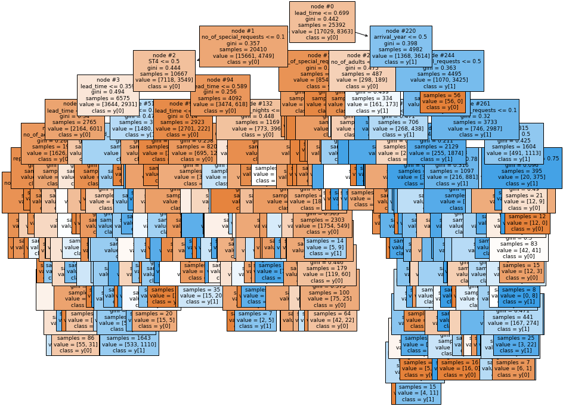

```python
plt.figure(figsize=(15, 12))

tree.plot_tree(
    estimator,
    feature_names=feature_names,
    filled=True,
    fontsize=9,
    node_ids=True,
    class_names=True,
)
plt.show()
```

## Perform Cost Complexity Pruning (Post-Pruning)

```python
clf = DecisionTreeClassifier(random_state=1)
path = clf.cost_complexity_pruning_path(X_train, y_train)
ccp_alphas, impurities = path.ccp_alphas, path.impurities
```

```python
pd.DataFrame(path)
```

|  | ccp_alphas | impurities |
| --- | --- | --- |
| 0 | 0.000000e+00 | 0.094103 |
| 1 | -2.710505e-20 | 0.094103 |
| 2 | -2.710505e-20 | 0.094103 |
| 3 | 0.000000e+00 | 0.094103 |
| 4 | 0.000000e+00 | 0.094103 |
| ... | ... | ... |
| 2054 | 3.958875e-03 | 0.301323 |
| 2055 | 4.542523e-03 | 0.305866 |
| 2056 | 4.837524e-03 | 0.310703 |
| 2057 | 1.815996e-02 | 0.365183 |
| 2058 | 7.657789e-02 | 0.441761 |

2059 rows × 2 columns

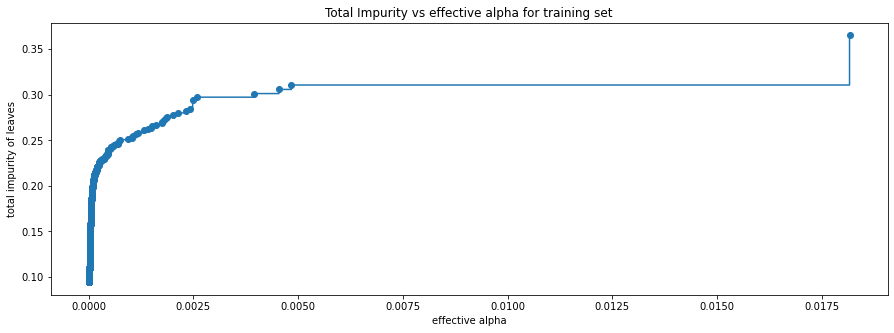

```python
fig, ax = plt.subplots(figsize=(15, 5))
ax.plot(ccp_alphas[:-1], impurities[:-1], marker="o", drawstyle="steps-post")
ax.set_xlabel("effective alpha")
ax.set_ylabel("total impurity of leaves")
ax.set_title("Total Impurity vs effective alpha for training set")
plt.show()
```

```python
ccp_alphas = [alpha for alpha in ccp_alphas if alpha >= 0.0]
```

```python
clfs = []
for ccp_alpha in ccp_alphas:
    clf = DecisionTreeClassifier(random_state=1, ccp_alpha=ccp_alpha)
    clf.fit(X_train, y_train)
    clfs.append(clf)
print(
    "Number of nodes in the last tree is: {} with ccp_alpha: {}".format(
        clfs[-1].tree_.node_count, ccp_alphas[-1]
    )
)
```

```
Number of nodes in the last tree is: 1 with ccp_alpha: 0.07657789477371324
```

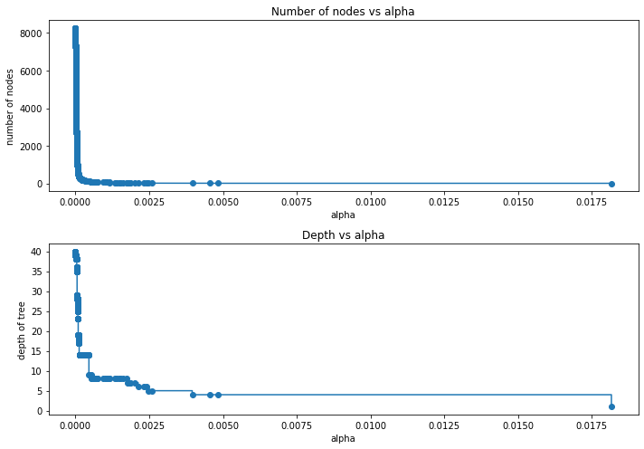

```python
clfs = clfs[:-1]
ccp_alphas = ccp_alphas[:-1]

node_counts = [clf.tree_.node_count for clf in clfs]
depth = [clf.tree_.max_depth for clf in clfs]
fig, ax = plt.subplots(2, 1, figsize=(10, 7))
ax[0].plot(ccp_alphas, node_counts, marker="o", drawstyle="steps-post")
ax[0].set_xlabel("alpha")
ax[0].set_ylabel("number of nodes")
ax[0].set_title("Number of nodes vs alpha")
ax[1].plot(ccp_alphas, depth, marker="o", drawstyle="steps-post")
ax[1].set_xlabel("alpha")
ax[1].set_ylabel("depth of tree")
ax[1].set_title("Depth vs alpha")
fig.tight_layout()
```

```python
recall_train = []
for clf in clfs:
    pred_train = clf.predict(X_train)
    values_train = recall_score(y_train, pred_train)
    recall_train.append(values_train)
```

```python
recall_test = []
for clf in clfs:
    pred_test = clf.predict(X_test)
    values_test = recall_score(y_test, pred_test)
    recall_test.append(values_test)
```

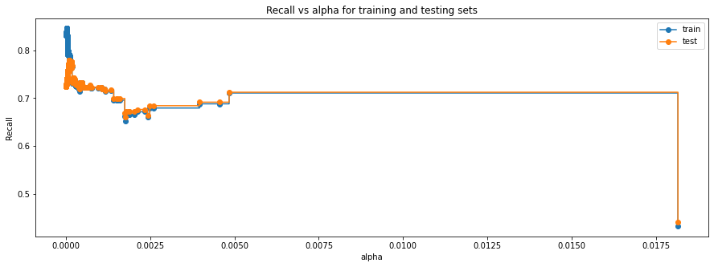

```python
fig, ax = plt.subplots(figsize=(15, 5))
ax.set_xlabel("alpha")
ax.set_ylabel("Recall")
ax.set_title("Recall vs alpha for training and testing sets")
ax.plot(ccp_alphas, recall_train, marker="o", label="train", drawstyle="steps-post")
ax.plot(ccp_alphas, recall_test, marker="o", label="test", drawstyle="steps-post")
ax.legend()
plt.show()
```

```python
index_best_model = np.argmax(recall_test)
best_model = clfs[index_best_model]
print(best_model)
```

```
DecisionTreeClassifier(ccp_alpha=9.574489429587162e-05, random_state=1)
```

```python
decision_tree_postpruned_perf_train = model_performance_classification_sklearn(
    best_model, X_train, y_train
)
decision_tree_postpruned_perf_train
```

|  | Accuracy | Recall | Precision | F1 |
| --- | --- | --- | --- | --- |
| 0 | 0.861216 | 0.791702 | 0.787933 | 0.789813 |

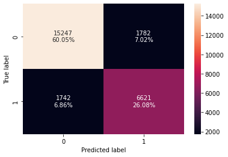

```python
confusion_matrix_sklearn(best_model, X_train, y_train)
```

```python
decision_tree_postpruned_perf_test = model_performance_classification_sklearn(
    best_model, X_test, y_test
)
decision_tree_postpruned_perf_test
```

|  | Accuracy | Recall | Precision | F1 |
| --- | --- | --- | --- | --- |
| 0 | 0.848296 | 0.778819 | 0.758783 | 0.76867 |

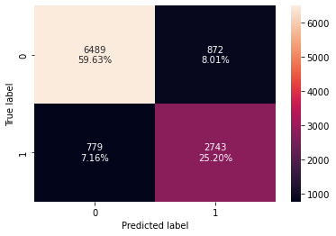

```python
confusion_matrix_sklearn(best_model, X_test, y_test)
```

## Visualize the Optimal Decision Tree

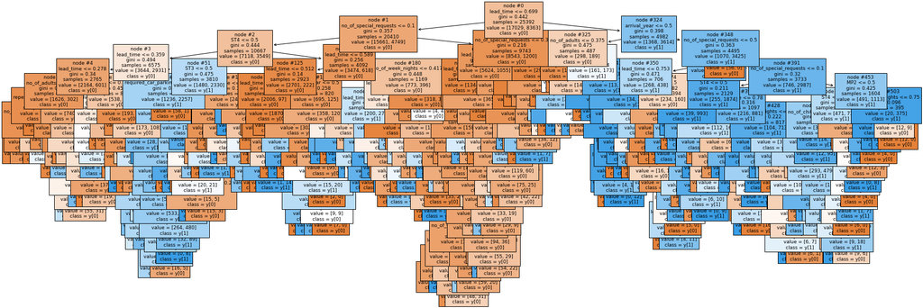

```python
plt.figure(figsize=(30, 10))

out = tree.plot_tree(
    best_model,
    feature_names=feature_names,
    filled=True,
    fontsize=9,
    node_ids=True,
    class_names=True,
)
for o in out:
    arrow = o.arrow_patch
    if arrow is not None:
        arrow.set_edgecolor("black")
        arrow.set_linewidth(1)
plt.show()
plt.show()
```

## Get Feature Importances

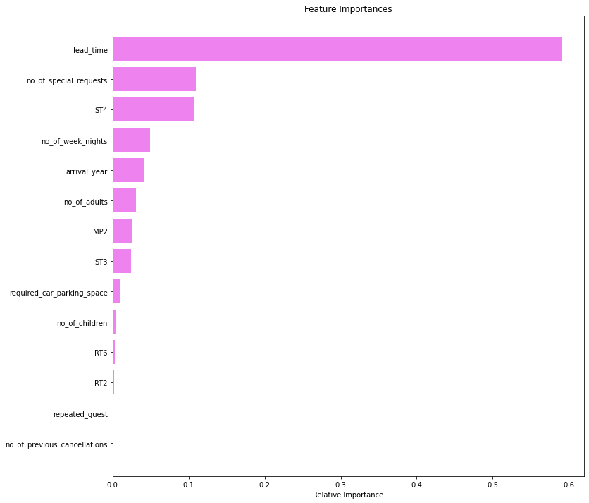

```python
importances = best_model.feature_importances_
indices = np.argsort(importances)

plt.figure(figsize=(12, 12))
plt.title("Feature Importances")
plt.barh(range(len(indices)), importances[indices], color="violet", align="center")
plt.yticks(range(len(indices)), [feature_names[i] for i in indices])
plt.xlabel("Relative Importance")
plt.show()
```

## Observations

- lead time is by far the most important feature.
- number of special requests and ST4 both have a high level of signifance.
- number of week nights, arrival year, number of adults, MP2, ST3, and required car parking space have some level of predictive ability.

## Model Performance Comparison and Conclusions

```python
# training performance comparison

models_train_comp_df = pd.concat(
    [
        decision_tree_perf_train.T,
        decision_tree_tune_perf_train.T,
        decision_tree_postpruned_perf_train.T,
    ],
    axis=1,
)
models_train_comp_df.columns = [
    "Decision Tree sklearn",
    "Decision Tree (Pre-Pruning)",
    "Decision Tree (Post-Pruning)",
]
print("Training performance comparison:")
models_train_comp_df
```

```
Training performance comparison:
```

|  | Decision Tree sklearn | Decision Tree (Pre-Pruning) | Decision Tree (Post-Pruning) |
| --- | --- | --- | --- |
| Accuracy | 0.927339 | 0.854718 | 0.861216 |
| Recall | 0.831759 | 0.777592 | 0.791702 |
| Precision | 0.940763 | 0.780485 | 0.787933 |
| F1 | 0.882909 | 0.779036 | 0.789813 |

```python
# test performance comparison

models_train_comp_df = pd.concat(
    [
        decision_tree_perf_test.T,
        decision_tree_tune_perf_test.T,
        decision_tree_postpruned_perf_test.T,
    ],
    axis=1,
)
models_train_comp_df.columns = [
    "Decision Tree sklearn",
    "Decision Tree (Pre-Pruning)",
    "Decision Tree (Post-Pruning)",
]
print("Test set performance comparison:")
models_train_comp_df
```

```
Test set performance comparison:
```

|  | Decision Tree sklearn | Decision Tree (Pre-Pruning) | Decision Tree (Post-Pruning) |
| --- | --- | --- | --- |
| Accuracy | 0.845631 | 0.847101 | 0.848296 |
| Recall | 0.724872 | 0.773140 | 0.778819 |
| Precision | 0.782169 | 0.758919 | 0.758783 |
| F1 | 0.752431 | 0.765963 | 0.768670 |

**The post-pruning model performs the best on every metric except for Precision.**

## Actionable Insights and Recommendations

- What profitable policies for cancellations and refunds can the hotel adopt?
- What other recommedations would you suggest to the hotel?

## Compare the test set performance across all models

```python
models_train_comp_df = pd.concat(
    [
        decision_tree_perf_test.T,
        decision_tree_tune_perf_test.T,
        decision_tree_postpruned_perf_test.T,
        log_reg_model_test_perf.T,
        log_reg_model_test_perf_threshold_auc_roc.T,
        log_reg_model_test_perf_threshold_curve.T,
    ],
    axis=1,
)
models_train_comp_df.columns = [
    "Decision Tree sklearn",
    "Decision Tree (Pre-Pruning)",
    "Decision Tree (Post-Pruning)",
    "Logistic Regression statsmodel",
    "Logistic Regression-0.28 Threshold",
    "Logistic Regression-0.45 Threshold",
]
print("Test set performance comparison:")
models_train_comp_df
```

```
Test set performance comparison:
```

|  | Decision Tree sklearn | Decision Tree (Pre-Pruning) | Decision Tree (Post-Pruning) | Logistic Regression statsmodel | Logistic Regression-0.28 Threshold | Logistic Regression-0.45 Threshold |
| --- | --- | --- | --- | --- | --- | --- |
| Accuracy | 0.845631 | 0.847101 | 0.848296 | 0.795369 | 0.751080 | 0.795461 |
| Recall | 0.724872 | 0.773140 | 0.778819 | 0.607893 | 0.829358 | 0.674617 |
| Precision | 0.782169 | 0.758919 | 0.758783 | 0.716773 | 0.580831 | 0.687500 |
| F1 | 0.752431 | 0.765963 | 0.768670 | 0.657858 | 0.683195 | 0.680997 |

**It is immediately apparent that the decision tree vastly outperforms the logistic regression model on almost all measures.**

**The only exception to this is that the logistic regression model with a 0.28 threshold outperforms the decision tree models on recall.**

**Based on an assessment of the above models, the best model is likely the post-pruning decision tree.**

**Across all models, lead time and number of special requests have the highest feature importance**

- This corresponds to a high coefficient on the logistic regression model and a high feature importance score on the decision tree model.

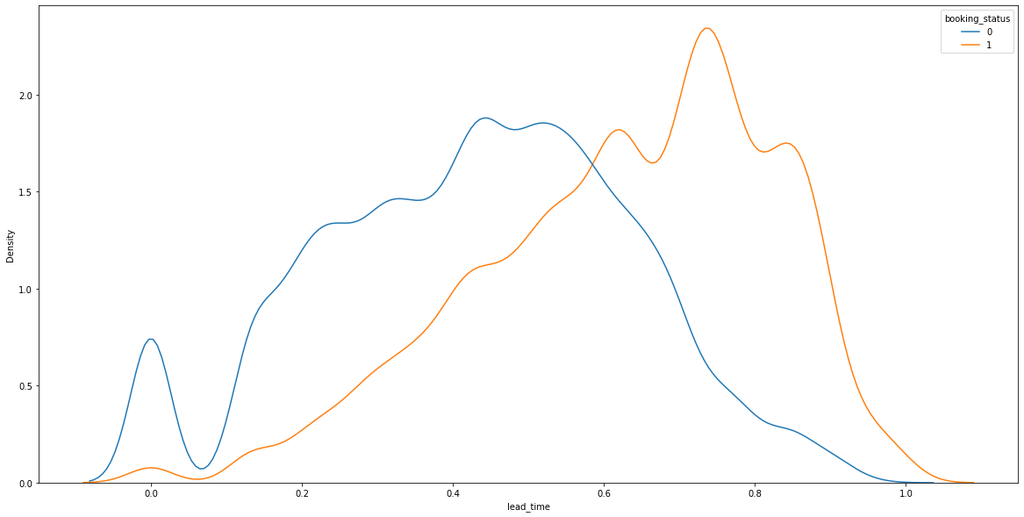

```python
plt.figure(figsize=(20, 10))
sns.kdeplot(data = hotel_data, x = 'lead_time', common_norm = False, hue = 'booking_status')
plt.show()
```

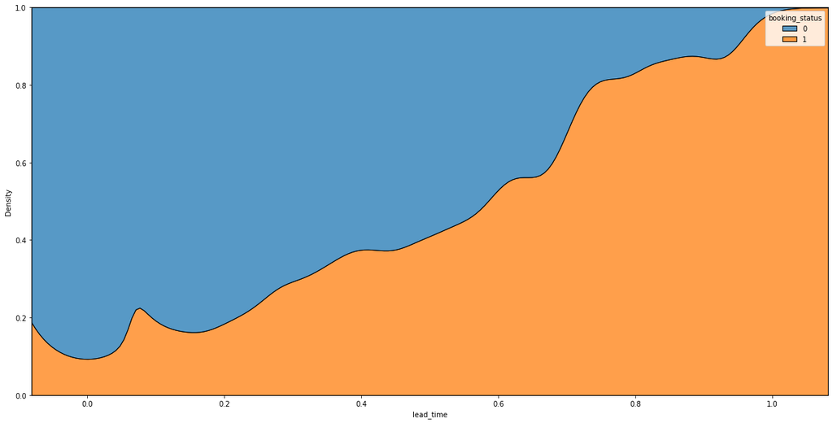

```python
plt.figure(figsize=(20, 10))
sns.kdeplot(data = hotel_data, x = 'lead_time', common_norm = False, hue = 'booking_status', multiple = 'fill')
plt.show()
```

**Based on the kdeplot, it is clear that bookings with a higher lead time are more likely to result in cancellation.**

- This is confirmed by the positive coefficient in the logistic regression model, meaning that a unit increase in lead time leads to an increase in cancellation (booking status = 1).

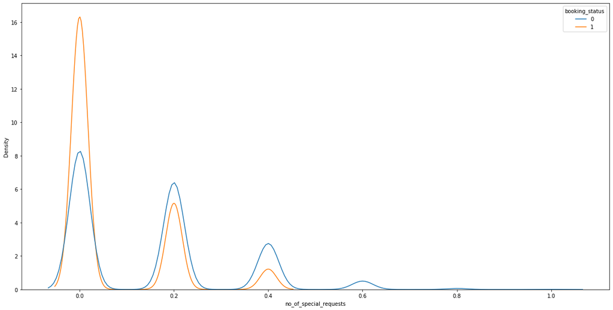

```python
plt.figure(figsize=(20, 10))
sns.kdeplot(data = hotel_data, x = 'no_of_special_requests', common_norm = False, hue = 'booking_status')
plt.show()
```

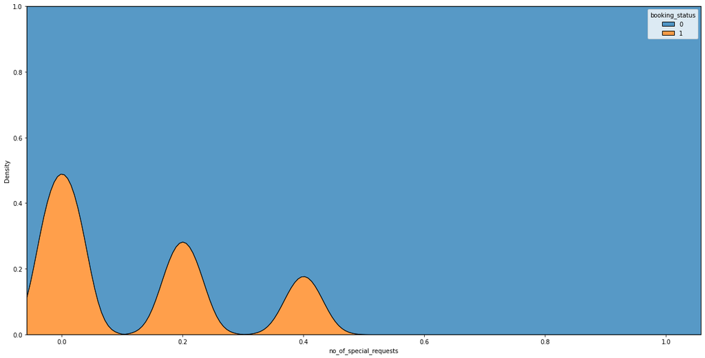

```python
plt.figure(figsize=(20, 10))
sns.kdeplot(data = hotel_data, x = 'no_of_special_requests', common_norm = True, hue = 'booking_status', multiple = 'fill')
plt.show()
```

**Based on the kdeplot above, it shows that bookings with a low number of special requests are more likely to cancel**

- This is confirmed by the high negative coefficient on no_of_special_requests in the logistic regression model.

## Conclusions

- Do not allows bookings with lead times exceeding 100 days, or place a premium on excessive lead times.
- Give discounts to customers who have special requests. Also, be weary of customers who have no special requests.
- Bookings with more children have a higher chance of cancelling.
- People who book which have canceled in the past are more likely to cancel in the future.
- People in market segment ST4 are less likely to cancel.
- The more week nights the booking is made for, the less likely they are to cancel.